# Project: Investigate the TMDb-moveis dataset.

- Introduction
- Data Wrangling
- Exploratory Data Analysis
- Conclusions

## Introduction

> Movies have been always been one of the most popular entertainments in our life. With the development of the film making techniques, the film industry has grown more vigorously than ever before.

> Here, I explored the 'TMDb-Moveis' dataset. This dataset contains information about 10,000 movies collected from The Movie Database (TMDb), including user ratings and revenue. In the later analysis process, I focus on the following two main questions.

> **1. What features are associated to the movies that have high revenues ?**

> **2. What are the popularity trends of different movie genres from year to year ?**

```python
import pandas as pd
import matplotlib.pyplot as plt
import seaborn as sns
%matplotlib inline
```

## Data Wrangling

### General Properties

```python
#load data

df = pd.read_csv('tmdb-movies.csv')
df.head()
```

|  | id | imdb_id | popularity | budget | revenue | original_title | cast | homepage | director | tagline | ... | overview | runtime | genres | production_companies | release_date | vote_count | vote_average | release_year | budget_adj | revenue_adj |
| --- | --- | --- | --- | --- | --- | --- | --- | --- | --- | --- | --- | --- | --- | --- | --- | --- | --- | --- | --- | --- | --- |
| 0 | 135397 | tt0369610 | 32.985763 | 150000000 | 1513528810 | Jurassic World | Chris Pratt\|Bryce Dallas Howard\|Irrfan Khan\|Vi... | http://www.jurassicworld.com/ | Colin Trevorrow | The park is open. | ... | Twenty-two years after the events of Jurassic ... | 124 | Action\|Adventure\|Science Fiction\|Thriller | Universal Studios\|Amblin Entertainment\|Legenda... | 6/9/15 | 5562 | 6.5 | 2015 | 1.379999e+08 | 1.392446e+09 |
| 1 | 76341 | tt1392190 | 28.419936 | 150000000 | 378436354 | Mad Max: Fury Road | Tom Hardy\|Charlize Theron\|Hugh Keays-Byrne\|Nic... | http://www.madmaxmovie.com/ | George Miller | What a Lovely Day. | ... | An apocalyptic story set in the furthest reach... | 120 | Action\|Adventure\|Science Fiction\|Thriller | Village Roadshow Pictures\|Kennedy Miller Produ... | 5/13/15 | 6185 | 7.1 | 2015 | 1.379999e+08 | 3.481613e+08 |
| 2 | 262500 | tt2908446 | 13.112507 | 110000000 | 295238201 | Insurgent | Shailene Woodley\|Theo James\|Kate Winslet\|Ansel... | http://www.thedivergentseries.movie/#insurgent | Robert Schwentke | One Choice Can Destroy You | ... | Beatrice Prior must confront her inner demons ... | 119 | Adventure\|Science Fiction\|Thriller | Summit Entertainment\|Mandeville Films\|Red Wago... | 3/18/15 | 2480 | 6.3 | 2015 | 1.012000e+08 | 2.716190e+08 |
| 3 | 140607 | tt2488496 | 11.173104 | 200000000 | 2068178225 | Star Wars: The Force Awakens | Harrison Ford\|Mark Hamill\|Carrie Fisher\|Adam D... | http://www.starwars.com/films/star-wars-episod... | J.J. Abrams | Every generation has a story. | ... | Thirty years after defeating the Galactic Empi... | 136 | Action\|Adventure\|Science Fiction\|Fantasy | Lucasfilm\|Truenorth Productions\|Bad Robot | 12/15/15 | 5292 | 7.5 | 2015 | 1.839999e+08 | 1.902723e+09 |
| 4 | 168259 | tt2820852 | 9.335014 | 190000000 | 1506249360 | Furious 7 | Vin Diesel\|Paul Walker\|Jason Statham\|Michelle ... | http://www.furious7.com/ | James Wan | Vengeance Hits Home | ... | Deckard Shaw seeks revenge against Dominic Tor... | 137 | Action\|Crime\|Thriller | Universal Pictures\|Original Film\|Media Rights ... | 4/1/15 | 2947 | 7.3 | 2015 | 1.747999e+08 | 1.385749e+09 |

5 rows × 21 columns

```python
df.info()
```

```
<class 'pandas.core.frame.DataFrame'>
RangeIndex: 10866 entries, 0 to 10865
Data columns (total 21 columns):
id                      10866 non-null int64
imdb_id                 10856 non-null object
popularity              10866 non-null float64
budget                  10866 non-null int64
revenue                 10866 non-null int64
original_title          10866 non-null object
cast                    10790 non-null object
homepage                2936 non-null object
director                10822 non-null object
tagline                 8042 non-null object
keywords                9373 non-null object
overview                10862 non-null object
runtime                 10866 non-null int64
genres                  10843 non-null object
production_companies    9836 non-null object
release_date            10866 non-null object
vote_count              10866 non-null int64
vote_average            10866 non-null float64
release_year            10866 non-null int64
budget_adj              10866 non-null float64
revenue_adj             10866 non-null float64
dtypes: float64(4), int64(6), object(11)
memory usage: 1.7+ MB
```

```python
df.describe()
```

|  | id | popularity | budget | revenue | runtime | vote_count | vote_average | release_year | budget_adj | revenue_adj |
| --- | --- | --- | --- | --- | --- | --- | --- | --- | --- | --- |
| count | 10866.000000 | 10866.000000 | 1.086600e+04 | 1.086600e+04 | 10866.000000 | 10866.000000 | 10866.000000 | 10866.000000 | 1.086600e+04 | 1.086600e+04 |
| mean | 66064.177434 | 0.646441 | 1.462570e+07 | 3.982332e+07 | 102.070863 | 217.389748 | 5.974922 | 2001.322658 | 1.755104e+07 | 5.136436e+07 |
| std | 92130.136561 | 1.000185 | 3.091321e+07 | 1.170035e+08 | 31.381405 | 575.619058 | 0.935142 | 12.812941 | 3.430616e+07 | 1.446325e+08 |
| min | 5.000000 | 0.000065 | 0.000000e+00 | 0.000000e+00 | 0.000000 | 10.000000 | 1.500000 | 1960.000000 | 0.000000e+00 | 0.000000e+00 |
| 25% | 10596.250000 | 0.207583 | 0.000000e+00 | 0.000000e+00 | 90.000000 | 17.000000 | 5.400000 | 1995.000000 | 0.000000e+00 | 0.000000e+00 |
| 50% | 20669.000000 | 0.383856 | 0.000000e+00 | 0.000000e+00 | 99.000000 | 38.000000 | 6.000000 | 2006.000000 | 0.000000e+00 | 0.000000e+00 |
| 75% | 75610.000000 | 0.713817 | 1.500000e+07 | 2.400000e+07 | 111.000000 | 145.750000 | 6.600000 | 2011.000000 | 2.085325e+07 | 3.369710e+07 |
| max | 417859.000000 | 32.985763 | 4.250000e+08 | 2.781506e+09 | 900.000000 | 9767.000000 | 9.200000 | 2015.000000 | 4.250000e+08 | 2.827124e+09 |

### Data Cleaning

First, drop the following columns: 'cast','homepage','tagline','budget', 'revenue','overview','runtime', which are redundant.

```python
df = df.drop(columns=['cast','homepage','tagline','budget', 'revenue','overview','runtime'])
```

```python
df.columns
```

```
Index(['id', 'imdb_id', 'popularity', 'original_title', 'director', 'keywords',
       'genres', 'production_companies', 'release_date', 'vote_count',
       'vote_average', 'release_year', 'budget_adj', 'revenue_adj'],
      dtype='object')
```

Now, check missing data and drop NaNs in certain columns.

```python
df.isnull().sum()
```

```
id                         0
imdb_id                   10
popularity                 0
original_title             0
director                  44
keywords                1493
genres                    23
production_companies    1030
release_date               0
vote_count                 0
vote_average               0
release_year               0
budget_adj                 0
revenue_adj                0
dtype: int64
```

```python
df.dropna(subset=['genres'], inplace = True)
df['genres'].isnull().sum()
```

```
0
```

## Exploratory Data Analysis

## Q1. What features are associated to the movies that have high revenues ?

Check the distribution of the movies revnues.

```python
df = df.query('revenue_adj != 0' and 'budget_adj !=0')
df.shape
```

```
(5169, 14)
```

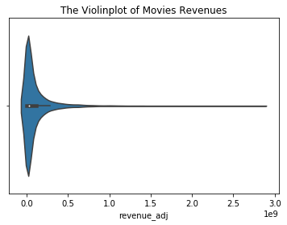

```python
ax = sns.violinplot(x='revenue_adj', data=df)

ax.set_title('The Violinplot of Movies Revenues');

plt.show()
```

> I define 'high revenues' to be the revenues greater than the revenues mean. Then, extrac the dataframe containing only the movies that have high revenues.

```python
mean = df[df['revenue_adj']!=0].revenue_adj.mean()
```

```python
df_high_revenue = df[df['revenue_adj'] > mean]
```

```python
df_high_revenue.head(2)
```

|  | id | imdb_id | popularity | original_title | director | keywords | genres | production_companies | release_date | vote_count | vote_average | release_year | budget_adj | revenue_adj |
| --- | --- | --- | --- | --- | --- | --- | --- | --- | --- | --- | --- | --- | --- | --- |
| 0 | 135397 | tt0369610 | 32.985763 | Jurassic World | Colin Trevorrow | monster\|dna\|tyrannosaurus rex\|velociraptor\|island | Action\|Adventure\|Science Fiction\|Thriller | Universal Studios\|Amblin Entertainment\|Legenda... | 6/9/15 | 5562 | 6.5 | 2015 | 1.379999e+08 | 1.392446e+09 |
| 1 | 76341 | tt1392190 | 28.419936 | Mad Max: Fury Road | George Miller | future\|chase\|post-apocalyptic\|dystopia\|australia | Action\|Adventure\|Science Fiction\|Thriller | Village Roadshow Pictures\|Kennedy Miller Produ... | 5/13/15 | 6185 | 7.1 | 2015 | 1.379999e+08 | 3.481613e+08 |

```python
df_high_revenue.shape
```

```
(1121, 14)
```

**1.Which months are more popular for movies that have high revenues ?**

To address this question, creat a new column df_high_revenue['release_month'] whoes values are extracted from df_high_revenue['release_date'].

```python
import warnings
warnings.filterwarnings("ignore")

df_high_revenue['release_month'] = df_high_revenue['release_date'].map(lambda x : int(x.split('/')[0]))
df_high_revenue.shape
```

```
(1121, 15)
```

```python
df_high_revenue['release_month'].unique()
```

```
array([ 6,  5,  3, 12,  4,  9, 10,  2,  7,  1, 11,  8])
```

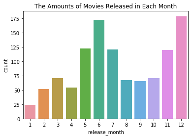

```python
ax = sns.countplot(df_high_revenue['release_month']);
ax.set_title('The Amounts of Movies Released in Each Month')
plt.show()
```

This plot tells us that movies that have higher revenues are more likely released in summer and Decembre.

**2. How the popularity and revenues relate ?**

Plot the distribution of the movies popularity.

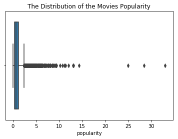

```python
ax = sns.boxplot(x='popularity',data = df);
ax.set_title('The Distribution of the Movies Popularity')
plt.show()
```

```
Text(0.5,1,'The scatter plot of popularity and revenues')
```

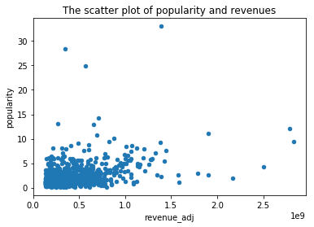

```python
ax = df_high_revenue.plot.scatter(x = 'revenue_adj',y= 'popularity');
ax.set_title('The scatter plot of popularity and revenues')
```

As shwon in this plot, the popularity and the revenes have no strongly corelation. Most of the movies have popularity under 10 and renuves under $10^9$.

**3. How the movie genres and renuves relate?**

To address this question, I will split the movie generes from the original column to certain single genre. First, I will extract all the movie genres in the dataset. Second, I will use apply function to obtain a new column with single genre value.

```python
genres = set(df.genres.apply(lambda x:str(x).split('|')).sum()) #find out all the movies genres in our dataset.

df_genre = pd.DataFrame() #creat an empty DataFrame.

for genre in genres:
    mask = df.genres.apply(lambda x : genre in str(x).split('|')) #create a new dataframe for each genre
    onedf = df[mask].assign(new_genre = genre)                    # add a column 'new_genre' filled up by the same value
    df_genre = df_genre.append(onedf,ignore_index = True)         # append all the new dataframes together

df_genre.head(2)
```

|  | id | imdb_id | popularity | original_title | director | keywords | genres | production_companies | release_date | vote_count | vote_average | release_year | budget_adj | revenue_adj | new_genre |
| --- | --- | --- | --- | --- | --- | --- | --- | --- | --- | --- | --- | --- | --- | --- | --- |
| 0 | 254470 | tt2848292 | 3.877764 | Pitch Perfect 2 | Elizabeth Banks | music\|sequel\|singer\|male female relationship\|a... | Comedy\|Music | Universal Pictures\|Gold Circle Films\|Brownston... | 5/7/15 | 1264 | 6.8 | 2015 | 2.667999e+07 | 2.645056e+08 | Music |
| 1 | 277216 | tt1398426 | 3.202719 | Straight Outta Compton | F. Gary Gray | brother brother relationship\|aids\|police bruta... | Drama\|Music | New Line Cinema\|Universal Pictures\|Legendary P... | 8/13/15 | 918 | 7.7 | 2015 | 2.575999e+07 | 1.855041e+08 | Music |

```python
df_genre_high_revenue = df_genre[df_genre['revenue_adj'] > mean] # this is a dataset with only the movies that have high revenue
df_genre_high_revenue.shape
```

```
(3320, 15)
```

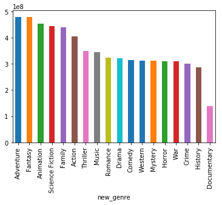

```python
# Apply groupy function on the column 'new_genre' and take the means of revenues.
genre_revenue = df_genre_high_revenue.groupby('new_genre')['revenue_adj'].mean().sort_values(ascending=False)
genre_revenue.plot(kind='bar');
```

This bar plot tells us that the movies of generes 'Adventure', 'Fantasy' and 'Animation' have the highest revenues.

**4. What is the revenues trends from year to year ?**

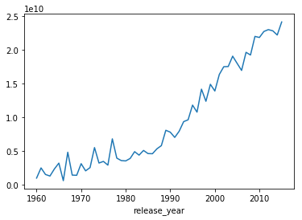

```python
df.groupby('release_year').sum()['revenue_adj'].plot(kind = 'line');
```

This plot shows that the total movie revenues are increasing year by year.

> Now I will starte to explore the second main question.

## Q2. What are the popularity trends of different movie genres from year to year ?

> I will take the popularity means of the movie genres as a metric.

```python
popularity_of_genres = df_genre.groupby('new_genre')['popularity'].mean().sort_values(ascending=False)
```

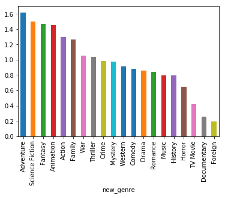

```python
popularity_of_genres.plot(kind='bar');
```

This plot sortes the popularity of each movie genre. In the next step, I will choose the top 9 most popular movie genres and analyze their popularity from year to year.

```python
most_popular_genres = popularity_of_genres.index[:9] # A list that contains top 9 the most popular movie genres
most_popular_genres
```

```
Index(['Adventure', 'Science Fiction', 'Fantasy', 'Animation', 'Action',
       'Family', 'War', 'Thriller', 'Crime'],
      dtype='object', name='new_genre')
```

```python
# Creat a new data frame containg only the movies genres that is in 'most_popular_genres'
df_most_popular_genres = df_genre[df_genre['new_genre'].isin(most_popular_genres)]
```

```python
set(df_most_popular_genres.new_genre.unique()) == set(most_popular_genres)# Check the columns
```

```
True
```

Next, I will creat a new DataFrame with columns = ['new_genres','release_year','popularity'].

```python
popularity_means = df_most_popular_genres.groupby(['new_genre','release_year']).mean()['popularity']
popularity_means.head()
```

```
new_genre  release_year
Action     1960            1.504538
           1961            0.397790
           1962            1.309838
           1963            1.165505
           1964            3.153791
Name: popularity, dtype: float64
```

```python
# creat a datafram who's values are popularity_means.

df_popularity = pd.DataFrame({'popularity': popularity_means}).reset_index()
df_popularity.head(2)
```

|  | new_genre | release_year | popularity |
| --- | --- | --- | --- |
| 0 | Action | 1960 | 1.504538 |
| 1 | Action | 1961 | 0.397790 |

```python
df_popularity.shape
```

```
(463, 3)
```

Reforme df_popularity and obtain a new dataframe with index='release_year' and columns='new_genre' and values='popularity'; see Reference 2.

```python
df_popularity = df_popularity.pivot(index='release_year', columns = 'new_genre', values = 'popularity')
```

```python
df_popularity.head()
```

| new_genre release_year | Action | Adventure | Animation | Crime | Family | Fantasy | Science Fiction | Thriller | War |
| --- | --- | --- | --- | --- | --- | --- | --- | --- | --- |
| 1960 | 1.504538 | 1.292261 | NaN | NaN | NaN | 0.712389 | 0.419804 | 1.215310 | NaN |
| 1961 | 0.397790 | 1.693268 | 2.631987 | 0.900245 | 1.467885 | NaN | NaN | NaN | 0.754548 |
| 1962 | 1.309838 | 1.621842 | NaN | 0.810805 | NaN | 0.235542 | 0.215748 | 1.358649 | 0.700762 |
| 1963 | 1.165505 | 0.876569 | NaN | 0.781120 | 0.178713 | 0.178713 | 0.334587 | 1.106811 | 0.664326 |
| 1964 | 3.153791 | 1.674366 | NaN | 0.663446 | 1.310850 | 1.987819 | 0.178025 | 1.908618 | 2.210475 |

```python
df_popularity.dropna(inplace=True) #drop NaNs
df_popularity.isnull().sum().sum()
```

```
0
```

```python
df_popularity.reset_index(level=0,inplace= True)
df_popularity.head(2)
```

| new_genre | release_year | Action | Adventure | Animation | Crime | Family | Fantasy | Science Fiction | Thriller | War |
| --- | --- | --- | --- | --- | --- | --- | --- | --- | --- | --- |
| 0 | 1967 | 1.338467 | 1.361477 | 1.348805 | 0.598588 | 1.395994 | 0.241283 | 0.109398 | 0.856507 | 0.485288 |
| 1 | 1977 | 2.390172 | 2.252783 | 0.828099 | 0.495480 | 0.971997 | 0.743112 | 2.098080 | 0.672588 | 0.641099 |

```python
max_popularity = df_popularity.drop('release_year',axis=1).max().max() # the maximal popularity value
```

```python
max_popularity
```

```
5.378318031250001
```

Plot the popularity trends of each mvoive genres from 1970 to 2015. For the plot, see Reference 1.

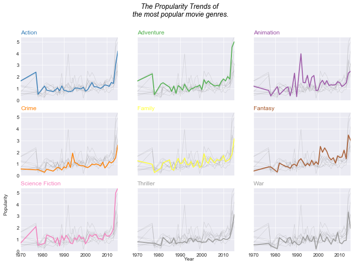

```python
import warnings
warnings.filterwarnings("ignore")

# Initialize the figure
plt.style.use('seaborn-darkgrid')
plt.figure(figsize=(12,8))

# create a color palette
palette = plt.get_cmap('Set1')

# multiple line plot
num=0
for column in df_popularity.drop('release_year', axis=1):
    num+=1

    # Find the right spot on the plot
    plt.subplot(3,3, num)

    # plot every groups, but discreet
    for v in df_popularity.drop('release_year', axis=1):
        plt.plot(df_popularity['release_year'], df_popularity[v], marker='', color='grey', linewidth=0.6, alpha=0.3)


    # Plot the lineplot

    plt.plot(df_popularity['release_year'], df_popularity[column], marker='', color=palette(1.*num/9), linewidth=1.9, alpha=0.9, label=column)

    # Same limits for everybody!
    plt.xlim(1970,2015) # x-axis is the years
    plt.ylim(0,max_popularity) # y-axis is the popularity

    # Not ticks everywhere
    if num in range(7) :
        plt.tick_params(labelbottom='off')
    if num not in [1,4,7] :
        plt.tick_params(labelleft='off')

    # Add title
    plt.title(column, loc='left', fontsize=12, fontweight=0, color=palette(1.*num/9) )

# general title
plt.suptitle("The Propularity Trends of \nthe most popular movie genres.", fontsize=14, fontweight=0, color='black', style='italic', y=1);

# Axis title
plt.text(1940, -0.7, 'Year', ha='center', va='center')
plt.text(1855, 4, 'Popularity', ha='center', va='center', rotation='vertical')
plt.show()

# This is one plot, I do not want to add x-axis and y-axis to every subplot.
```

## Conclusions

> Although we draw several conlusions for the above analysis process, after cleaning the NaN and zero values, this dataset is too small to be an effective representation of the population. Therefore, thoses conclusions stated above are not of pratical significance to the film industry.

**References.**

> 1. Small multiples for line chart. https://python-graph-gallery.com/125-small-multiples-for-line-chart/
> 2. pandas.DataFrame.pivot. https://pandas.pydata.org/pandas-docs/stable/generated/pandas.DataFrame.pivot.html

```python
from subprocess import call
call(['python', '-m', 'nbconvert', 'Investigate_a_Dataset.ipynb'])
```

```
255
```